# Analysing ToothGrowth Dataset

Shirley Asangi

# Exploratory Data Analysis

First, lets just see the summary of dataset

```r
summary(ToothGrowth)
```

```
##       len        supp         dose
##  Min.   : 4.20   OJ:30   Min.   :0.500
##  1st Qu.:13.07   VC:30   1st Qu.:0.500
##  Median :19.25           Median :1.000
##  Mean   :18.81           Mean   :1.167
##  3rd Qu.:25.27           3rd Qu.:2.000
##  Max.   :33.90           Max.   :2.000
```

Lets see Average Length Growth for each supp

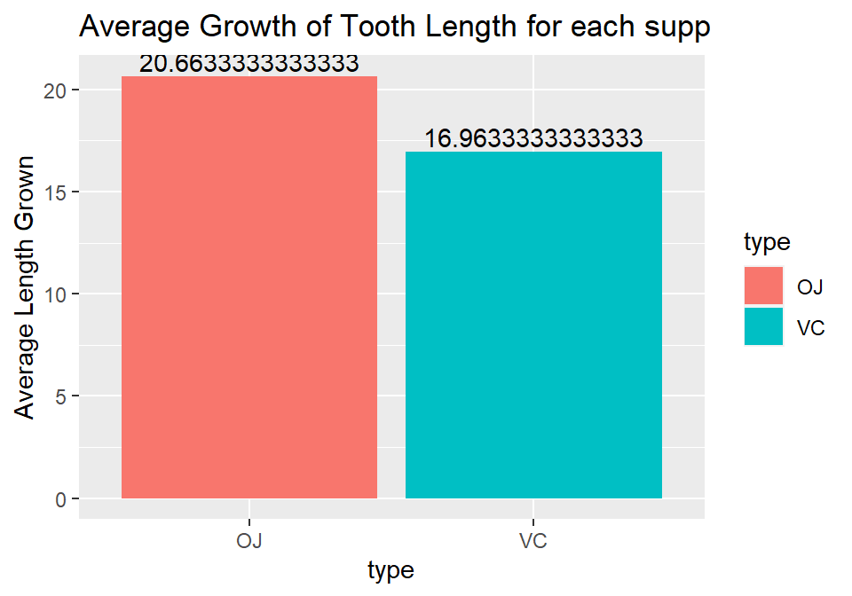

Mean of the Teeth Growth Length for each type

```r
library(ggplot2)
toothgrowth <- ToothGrowth
mean.len <- with(toothgrowth,tapply(len, supp, mean))
type <- c("OJ","VC")
avg.data <- data.frame(avg=mean.len,type=type)
g <- ggplot(avg.data,aes(x=type,y=avg)) + geom_bar(aes(fill=type),stat = 'identity') +
ylab("Average Length Grown")+ geom_text(aes(label=avg), position=
position_dodge(width=0.9), vjust=-0.25) + ggtitle("Average Growth of Tooth Length for each supp")
g
```

So,Average Length of Tooth Growth is higher for supp “OJ” than “VC”.

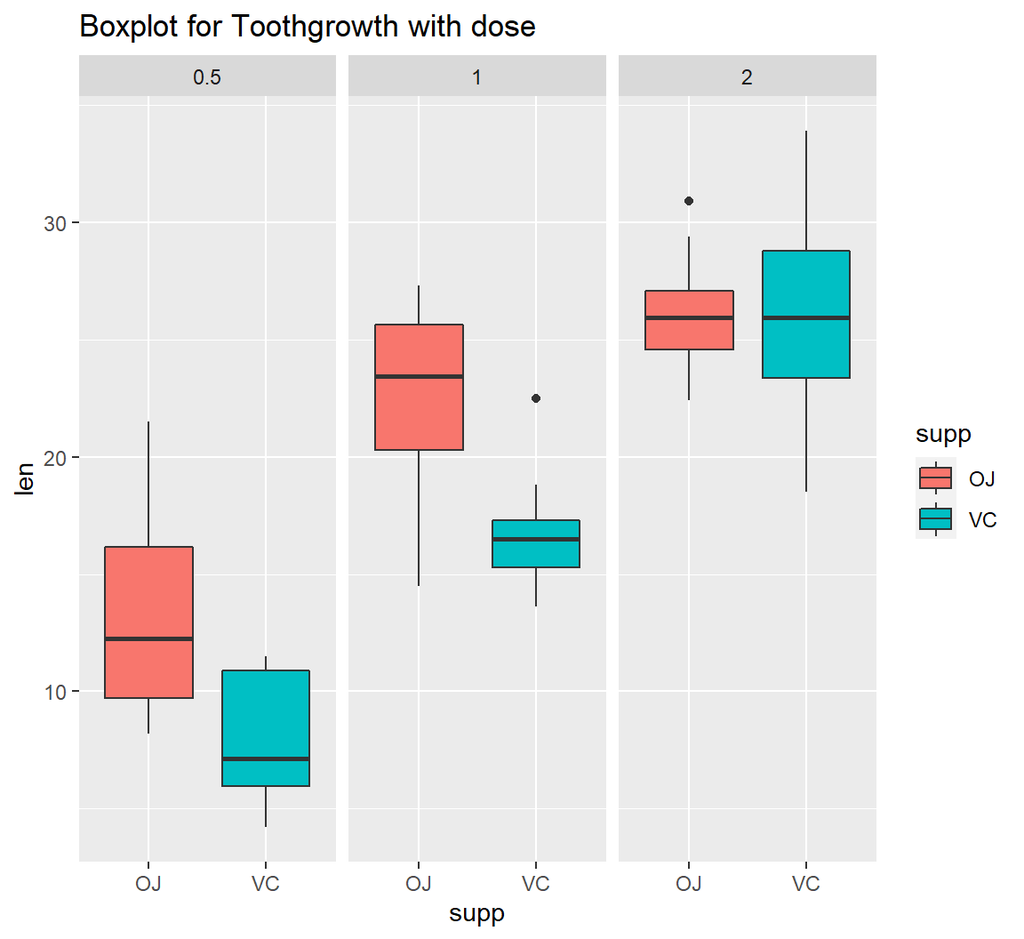

```r
ggplot(ToothGrowth,aes(x=supp,y=len)) + geom_boxplot(aes(fill=supp)) + facet_grid(.~dose) +
  ggtitle("Boxplot for Toothgrowth with dose ")
```

So the Box Plot shows that as concentration of dose increases Tooth Growth also increases.This is visible for both “OJ” and “VC”.For the case of “VC” there is significant improvement from dosage of 1 to 2, while that is not the case for “OJ”.

# Hypothesis Testing

There are two features in this dataset on which Hypothesis Testing can be performed: 1) Hypothesis Test on “supp” i.e supplement type 2) Hypothesis Test on the “dose”

## Hypothesis Test on “supp”

Let our Null Hypothesis be that there is no difference in toothgrowth due to supplement type.

**Null Hypothesis:** Toothgrowth due to “OJ” = Toothgrowth due to “VC”

**Alternative Hypothesis:** Toothgrowth due to “OJ” > Toothgrowth due to “VC”

```r
oj.data <- subset(ToothGrowth,supp=="OJ")
vc.data <- subset(ToothGrowth,supp=="VC")
t.test(x=oj.data$len,y=vc.data$len,alternative='greater',var.equal=FALSE,paired=FALSE)
```

```
##
##  Welch Two Sample t-test
##
## data:  oj.data$len and vc.data$len
## t = 1.9153, df = 55.309, p-value = 0.03032
## alternative hypothesis: true difference in means is greater than 0
## 95 percent confidence interval:
##  0.4682687       Inf
## sample estimates:
## mean of x mean of y
##  20.66333  16.96333
```

```r
dose1 <- subset(ToothGrowth,dose=="0.5")
dose2 <- subset(ToothGrowth,dose=="1")
dose3 <- subset(ToothGrowth,dose=="2")
```

**First for dose of 0.5mg and 1mg**

```r
t.test(x=dose1$len,y=dose2$len,alternative="less",paired=FALSE,var.equal=FALSE)
```

```
##
##  Welch Two Sample t-test
##
## data:  dose1$len and dose2$len
## t = -6.4766, df = 37.986, p-value = 6.342e-08
## alternative hypothesis: true difference in means is less than 0
## 95 percent confidence interval:
##       -Inf -6.753323
## sample estimates:
## mean of x mean of y
##    10.605    19.735
```

So p-value is 6.342e-08 which is very less than alpha=0.05 so we reject the null hypothesis,this means that Toothgrowth for dose of 0.5mg is less than Toothgrowth for dose of 1mg.

**First for dose of 1mg and 2mg**

```r
t.test(x=dose2$len,y=dose3$len,alternative="less",paired=FALSE,var.equal=FALSE)
```

```
##
##  Welch Two Sample t-test
##
## data:  dose2$len and dose3$len
## t = -4.9005, df = 37.101, p-value = 9.532e-06
## alternative hypothesis: true difference in means is less than 0
## 95 percent confidence interval:
##      -Inf -4.17387
## sample estimates:
## mean of x mean of y
##    19.735    26.100
```

The p-value is 9.532e-06 again it is very less than alpha=0.05 so we reject the null hypothesis,this means Toothgrowth for dose of 1mg is less than Toothgrowth for 2mg.

# Assumptions

1)Variance between supplement types and dose is not equal. 2)The Data is non-paired i.e experiments are done on different subjects for each supp and dose. 3)The variables are independent and identically distributed.

# Conclusions

1)Supplement type “OJ” gives more Toothgrowth than the supplement type “VC” 2)Toothgrowth increases as the concentation or power od dosage increases.